# Informe estadístico - Pingüinos Palmer

**Asignatura:** II4D3 - Estadística I  
**Profesor:** Ing. Sebastián Blandón Londoño  
Nombre del Programa Académico  
Facultad de Ciencias Empresariales  
*Universidad Tecnológica de Pereira*

Autor

[Sebastián Blandón Londoño](https://www.linkedin.com/in/sebastian-blandon/)

Fecha de publicación

26/03/2025

# Preparación

## Carga de librerías

**Código**

```r
library(palmerpenguins) # para cargar los datos de los pinguinos
library(openxlsx) # para gestionar archivos de excel
library(jsonlite) # para gestionar archivos json
library(janitor) # para limpiar los nombres de las columnas
library(dplyr) # para el operador pipe y transformar datos. Hace parte del tidyverse
library(skimr) # Resumen automatizado de datasets
library(ggplot2) # para hacer graficas. Hace parte del tidyverse
library(forcats) # para manejar factores (Variables categoricas)
library(glue) # para pegar texto con variables
```

## Carga de datos

**Código**

```r
# 1. Usando la libreria
datos_estadistica <- palmerpenguins::penguins_raw

# 2. Usando archivo csv
#datos_estadistica <- read.csv("Datos_Pinguinos.csv")

# 3. Usando archivo de excel (xlsx)
#datos_estadistica <- read.xlsx("Datos_Pinguinos.xlsx")

# 4. Usando un archivo json
#datos_estadistica <- read_json("Datos_Pinguinos.json")

datos_estadistica <- datos_estadistica %>%
  clean_names() %>%
  rename(
    delta_15N = delta_15_n_o_oo,
    delta_13C = delta_13_c_o_oo
  )

# Esta es la forma sin usar pipe ( %>% )
#datos_estadistica <- clean_names(dat = datos_estadistica)
names(datos_estadistica)[names(datos_estadistica) == "delta_15_n_o_oo"] <- "delta_15N"
names(datos_estadistica)[names(datos_estadistica) == "delta_13_c_o_oo"] <- "delta_13C"
```

# Análisis preliminar

## Integridad de cada variable

**species**

- Cantidad NA: `0`
- Tipo de variable: `character`

**region**

- Cantidad NA: `0`
- Tipo de variable: `character`

**island**

- Cantidad NA: `0`
- Tipo de variable: `character`

**stage**

- Cantidad NA: `0`
- Tipo de variable: `character`

**individual_id**

- Cantidad NA: `0`
- Tipo de variable: `character`

**clutch_completion**

- Cantidad NA: `0`
- Tipo de variable: `character`

**date_egg**

- Cantidad NA: `0`
- Tipo de variable: `Date`

**culmen_length_mm**

- Cantidad NA: `2`
- Tipo de variable: `numeric`

**culmen_depth_mm**

- Cantidad NA: `2`
- Tipo de variable: `numeric`

**flipper_length_mm**

- Cantidad NA: `2`
- Tipo de variable: `numeric`

**body_mass_g**

- Cantidad NA: `2`
- Tipo de variable: `numeric`

**sex**

- Cantidad NA: `11`
- Tipo de variable: `character`

**delta_15N**

- Cantidad NA: `14`
- Tipo de variable: `numeric`

**delta_13C**

- Cantidad NA: `13`
- Tipo de variable: `numeric`

## Valores de cada variable

### Variables “numeric”

**culmen_depth_mm**

- Cantidad de observaciones: `342`
- Media: `17.1511696`
- Mediana: `17.3`
- Máximo: `21.5`
- Mínimo: `13.1`
- Rango: `8.4`
- Varianza: `3.899808`
- Desviación estándar: `1.9747932`
- Q1 (25%): `15.6`
- Q2 (50%): `17.3`
- Q3 (75%): `18.7`

**flipper_length_mm**

- Cantidad de observaciones: `342`
- Media: `200.9152047`
- Mediana: `197`
- Máximo: `231`
- Mínimo: `172`
- Rango: `59`
- Varianza: `197.7317916`
- Desviación estándar: `14.0617137`
- Q1 (25%): `190`
- Q2 (50%): `197`
- Q3 (75%): `213`

**body_mass_g**

- Cantidad de observaciones: `342`
- Media: `4201.754386`
- Mediana: `4050`
- Máximo: `6300`
- Mínimo: `2700`
- Rango: `3600`
- Varianza: `6.4313108\times 10^{5}`
- Desviación estándar: `801.9545357`
- Q1 (25%): `3550`
- Q2 (50%): `4050`
- Q3 (75%): `4750`

**delta_15N**

- Cantidad de observaciones: `330`
- Media: `8.7333817`
- Mediana: `8.652405`
- Máximo: `10.02544`
- Mínimo: `7.6322`
- Rango: `2.39324`
- Varianza: `0.3044505`
- Desviación estándar: `0.5517703`
- Q1 (25%): `8.29989`
- Q2 (50%): `8.652405`
- Q3 (75%): `9.1721225`

**delta_13C**

- Cantidad de observaciones: `331`
- Media: `-25.6862915`
- Mediana: `-25.83352`
- Máximo: `-23.78767`
- Mínimo: `-27.01854`
- Rango: `3.23087`
- Varianza: `0.6303744`
- Desviación estándar: `0.7939612`
- Q1 (25%): `-26.320305`
- Q2 (50%): `-25.83352`
- Q3 (75%): `-25.06205`

### Variables “character”

**sex**

- Valores únicos: `MALE, FEMALE, NA`

**species**

- Valores únicos: `Adelie Penguin (Pygoscelis adeliae), Gentoo penguin (Pygoscelis papua), Chinstrap penguin (Pygoscelis antarctica)`

**region**

- Valores únicos: `Anvers`

**island**

- Valores únicos: `Torgersen, Biscoe, Dream`

**stage**

- Valores únicos: `Adult, 1 Egg Stage`

**clutch_completion**

- Valores únicos: `Yes, No`

### Variables “date”

**date_egg**

- Fecha máxima: `2009-12-01`
- Fecha mínima: `2007-11-09`
- Fecha mediana: `2008-11-09`

## Resumen automatizado

**Código**

```r
skim(datos_estadistica)
```

Data summary

| Name | datos_estadistica |
| --- | --- |
| Number of rows | 344 |
| Number of columns | 17 |
| _______________________ |  |
| Column type frequency: |  |
| character | 9 |
| Date | 1 |
| numeric | 7 |
| ________________________ |  |
| Group variables | None |

**Variable type: character**

| skim_variable | n_missing | complete_rate | min | max | empty | n_unique | whitespace |
| --- | --- | --- | --- | --- | --- | --- | --- |
| study_name | 0 | 1.00 | 7 | 7 | 0 | 3 | 0 |
| species | 0 | 1.00 | 33 | 41 | 0 | 3 | 0 |
| region | 0 | 1.00 | 6 | 6 | 0 | 1 | 0 |
| island | 0 | 1.00 | 5 | 9 | 0 | 3 | 0 |
| stage | 0 | 1.00 | 18 | 18 | 0 | 1 | 0 |
| individual_id | 0 | 1.00 | 4 | 6 | 0 | 190 | 0 |
| clutch_completion | 0 | 1.00 | 2 | 3 | 0 | 2 | 0 |
| sex | 11 | 0.97 | 4 | 6 | 0 | 2 | 0 |
| comments | 290 | 0.16 | 18 | 68 | 0 | 10 | 0 |

**Variable type: Date**

| skim_variable | n_missing | complete_rate | min | max | median | n_unique |
| --- | --- | --- | --- | --- | --- | --- |
| date_egg | 0 | 1 | 2007-11-09 | 2009-12-01 | 2008-11-09 | 50 |

**Variable type: numeric**

| skim_variable | n_missing | complete_rate | mean | sd | p0 | p25 | p50 | p75 | p100 | hist |
| --- | --- | --- | --- | --- | --- | --- | --- | --- | --- | --- |
| sample_number | 0 | 1.00 | 63.15 | 40.43 | 1.00 | 29.00 | 58.00 | 95.25 | 152.00 | ▇▇▆▅▃ |
| culmen_length_mm | 2 | 0.99 | 43.92 | 5.46 | 32.10 | 39.23 | 44.45 | 48.50 | 59.60 | ▃▇▇▆▁ |
| culmen_depth_mm | 2 | 0.99 | 17.15 | 1.97 | 13.10 | 15.60 | 17.30 | 18.70 | 21.50 | ▅▅▇▇▂ |
| flipper_length_mm | 2 | 0.99 | 200.92 | 14.06 | 172.00 | 190.00 | 197.00 | 213.00 | 231.00 | ▂▇▃▅▂ |
| body_mass_g | 2 | 0.99 | 4201.75 | 801.95 | 2700.00 | 3550.00 | 4050.00 | 4750.00 | 6300.00 | ▃▇▆▃▂ |
| delta_15N | 14 | 0.96 | 8.73 | 0.55 | 7.63 | 8.30 | 8.65 | 9.17 | 10.03 | ▃▇▆▅▂ |
| delta_13C | 13 | 0.96 | -25.69 | 0.79 | -27.02 | -26.32 | -25.83 | -25.06 | -23.79 | ▆▇▅▅▂ |

## Definir el tipo de cada variable

**Código**

```r
datos_estadistica <- datos_estadistica %>%
  mutate(
    study_name = as_factor(study_name),
    species = as_factor(species),
    region = as_factor(region),
    island = as_factor(island),
    stage = as_factor(stage),
    individual_id = as_factor(individual_id),
    clutch_completion = as_factor(clutch_completion),
    sex = as_factor(sex)
  )
```

# Algunas preguntas…

## ¿Cuáles son las especies de pingüinos incluidas en el estudio? ¿Cuántas especies hay?

En total, hay `3` especies diferentes, las cuales son: `Adelie Penguin (Pygoscelis adeliae), Gentoo penguin (Pygoscelis papua)`, y `Chinstrap penguin (Pygoscelis antarctica)`.

## ¿Hay una diferencia significativa en la longitud del pico entre machos y hembras?

**Código**

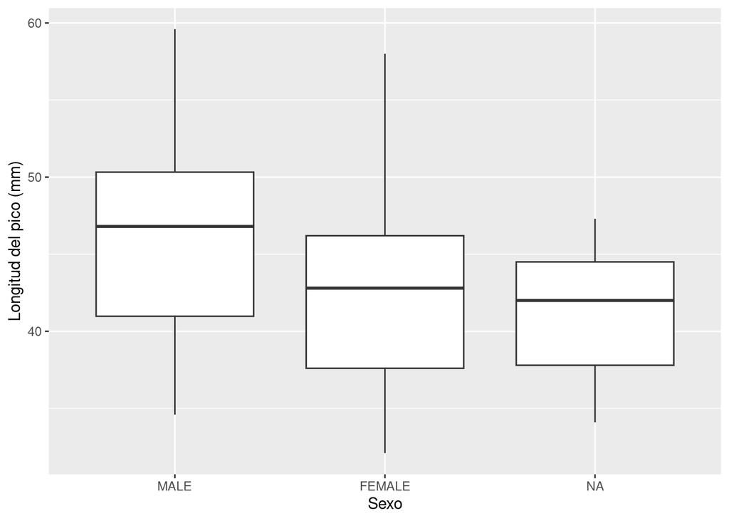

```r
datos_estadistica %>%
  ggplot(aes(x = sex, y = culmen_length_mm))+
  geom_boxplot() +
  labs(
    x = "Sexo",
    y = "Longitud del pico (mm)"
  )+
  theme(
    legend.position = "bottom"
  )
```

**Código**

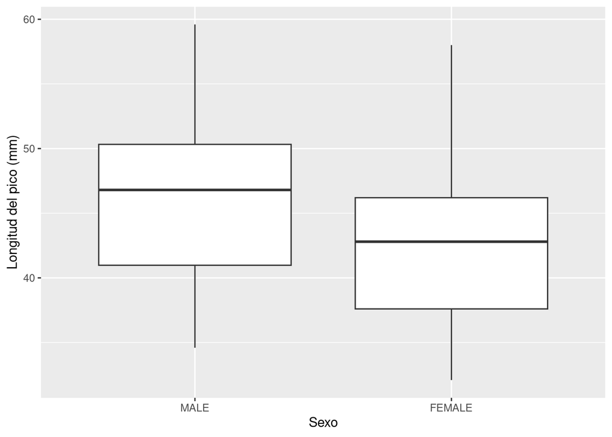

```r
datos_estadistica %>%
  filter(!is.na(sex)) %>%
  ggplot(aes(x = sex, y = culmen_length_mm))+
  geom_boxplot() +
  labs(
    x = "Sexo",
    y = "Longitud del pico (mm)"
  )+
  theme(
    legend.position = "bottom"
  )
```

## ¿Cuáles son las islas donde se aplicó el estudio?

**Opción 1:** El estudio de los “Pingüinos Palmer” fue aplicado en las islas `Torgersen, Biscoe, Dream`.

**Opción 2:** El estudio de los “Pingüinos Palmer” fue aplicado en las islas `Torgersen, Biscoe`, y `Dream`.

**Opción 3:** El estudio de los “Pingüinos Palmer” fue aplicado en las islas `Torgersen, Biscoe`, y `Dream`.

## ¿En cuál isla está la hembra con el pico más corto?

**Código**

```r
respuesta <- datos_estadistica %>%
  filter(sex == "FEMALE") %>%
  group_by(island) %>%
  summarise(
    culmen_length_mm = min(culmen_length_mm)
  )
```

La hembra con pico más corto está en la isla `Dream`, y tiene `32.1` mm de longitud.

## ¿En cuál isla están las hembras con el pico más corto?

**Código**

```r
respuesta <- datos_estadistica %>%
  filter(sex == "FEMALE") %>%
  group_by(island) %>%
  summarise(
    culmen_length_mm = mean(culmen_length_mm, na.rm = TRUE)
  )
```

Las hembras con el pico más corto están en la isla `Torgersen`, con una longitud promedio de `37.55`mm.

# Algunas gráficas

## Cantidad de pingüinos por sexo

**Código**

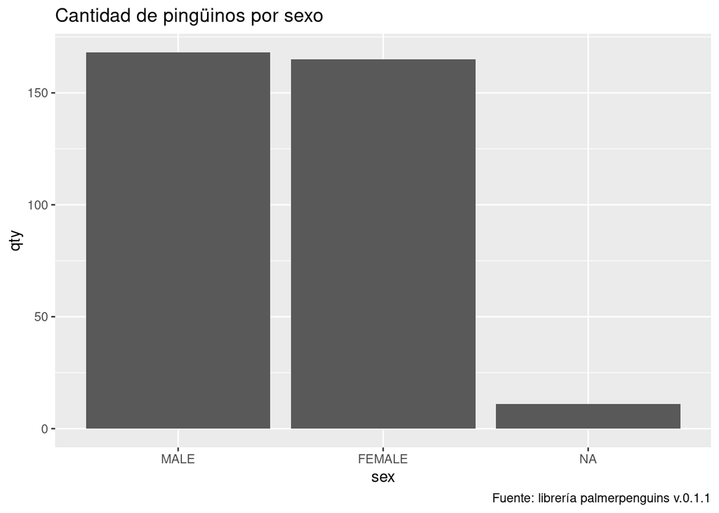

```r
respuesta <- datos_estadistica %>%
  group_by(sex) %>%
  mutate(
    contar = 1
    ) %>%
  summarise(qty = sum(contar)
  )

version_palmer <- as.character(packageVersion("palmerpenguins"))

ggplot(data = respuesta, aes(x = sex, y = qty)) +
  geom_bar(stat = "identity")+
  labs(
    title = "Cantidad de pingüinos por sexo",
    caption = glue("Fuente: librería palmerpenguins v.", {version_palmer})
  )
```